# ch03_05_02_DBSCAN

## ch03 DBSCAN : density-based clustering applications with noise

### 학습 내용

- 01 DBSCAN은 무엇인가?
- 02 DBSCAN에 대한 장점
- 03 DBSCAN의 원리 이해
- 04 알고리즘 동작 이해
- 05 실습해 보기

```python
from IPython.display import display, Image
```

### 01 DBSCAN은 무엇인가?

- 유용한 군집(Clustering) 알고리즘입니다.
- 데이터의 밀집 지역이 한 클러스터를 구성하며 비교적 비어 있는 지역을 경계로 다른 클러스터와 구분이 된다.

### 02 DBSCAN에 대한 장점

- DBSCAN의 장점은 클러스터 개수를 미리 지정할 필요가 없다.
- DBSCAN은 병합 군집이나 k-평균보다는 다소 느리지만 비교적 큰 데이터셋에도 적용이 가능하다.
- 어떤 클래스에도 속하지 않는 포인트를 구분할 수 있다.

### 03 DBSCAN의 원리 이해

```
알고리즘은 방문하지 않은 임의의 지점에서 시작한다. 주변 정보는 eps의 매개변수에 의해 검색된다.
(가) 특성 공간에서 가까이 있는 데이터가 많아 붐비는 지역의 포인트를 찾는다.
(나) 밀집 지역(dense region) - 붐비는 지역을 말한다.
(다) DBSCAN의 아이디어는 데이터의 밀집 지역이 한 클러스터를 구성하며 비교적 비어있는 지역을 경계로 다른 클러스터와 구분된다는 것이다.
```

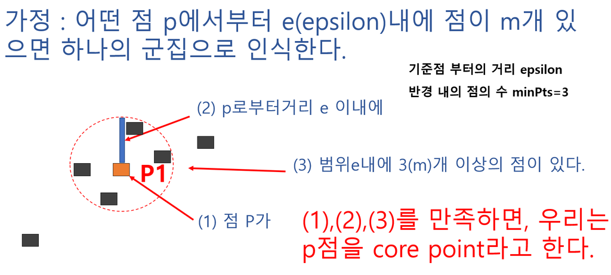

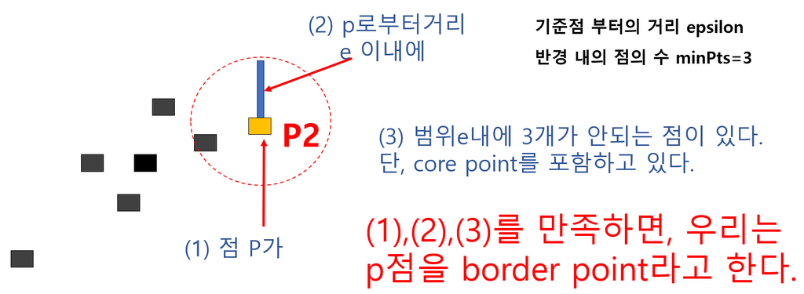

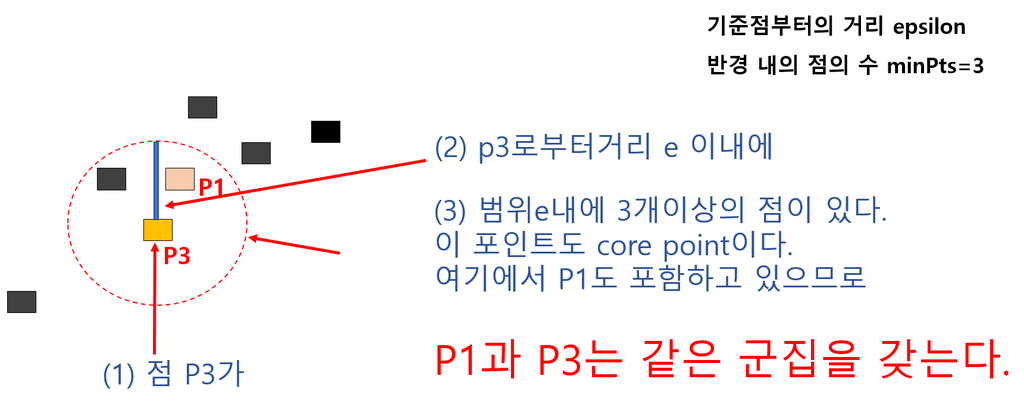

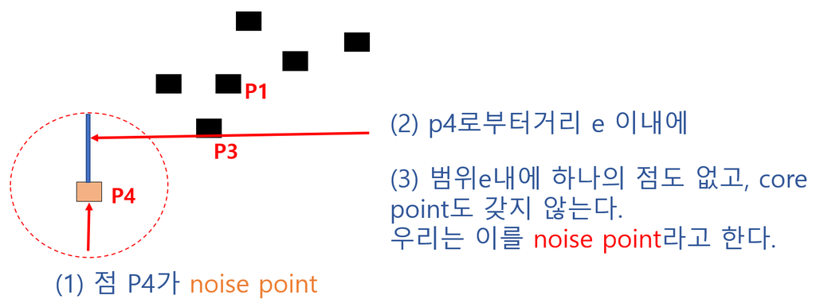

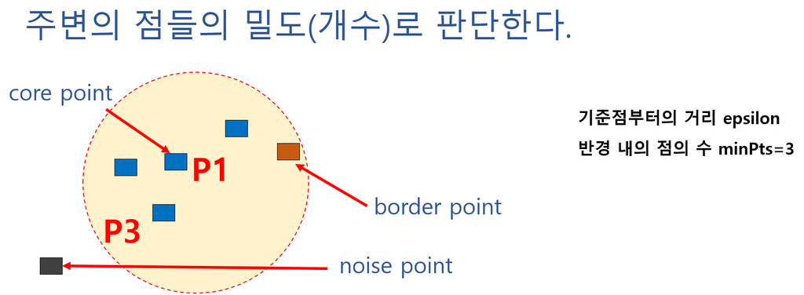

```python
display(Image(filename='img/DBSCAN01.png'))
display(Image(filename='img/DBSCAN02.png'))
display(Image(filename='img/DBSCAN03.png'))
display(Image(filename='img/DBSCAN04.png'))
display(Image(filename='img/DBSCAN05.png'))
```

```python
import mglearn
import matplotlib.pyplot as plt

### 한글
import matplotlib
from matplotlib import font_manager, rc
font_loc = "C:/Windows/Fonts/malgunbd.ttf"
font_name = font_manager.FontProperties(fname=font_loc).get_name()
matplotlib.rc('font', family=font_name)

### 마이너스 설정
from matplotlib import rc
matplotlib.rc("axes", unicode_minus=False)
```

### 04 알고리즘 동작 이해하기

- (가) 시작할 때, 알고리즘이 방문하지 않은 무작위로 포인트를 선택
- (나) 그 포인트에서 eps거리안의 모든 포인트를 찾는다.
- (다) eps 거리안에 있는 포인트 수가 **핵심샘플도 없고, min_samples보다 적다면**
  - 어떤 클래스에도 속하지 않는 **잡음(noise)로 레이블**
- (라) eps 거리안에 **min_samples보다 많은 포인트**가 있다면 그 포인트는 핵심 샘플(core point)로 레이블.
  - 새로운 클러스터 레이블로 할당하고 그 포인트의 eps 거리안의 모든 이웃을 살핌.
  - 만약 어떤 클러스터에도 할당되어 있지 않으면 바로 전의 클러스터 레이블로 할당.
  - 만약 핵심 샘플이면 그 포인트의 이웃을 차례로 방문. 이런 형태로 클러스터는 eps 거리 안에 샘플이 없을 때까지 자라난다.
- (마) 그런다음 방문하지 못한 포인트를 방문하여 같은 과정을 반복함.
- DBSCAN은 클러스터의 개수를 지정할 필요는 없지만
  - eps의 값은 간접적으로 몇 개의 클러스터가 만들어질지 제어합니다.
    - eps를 매우 작게 하면 어떤 포인트도 핵심 포인트가 되지 않고, 모든 포인트가 잡음 포인트(noise point)가 될 수 있음.
    - eps를 매우 크게 하면 모든 포인트가 단 하나의 클러스터에 속하게 됨.
  - 적절한 eps값을 찾을 때는 StandardScaler나 MinMaxScaler로 모든 특성의 스케일을 비슷한 범위로 조정해 주는 것이 좋음.

```
min_samples: 2 eps: 1.000000  cluster: [-1  0  0 -1  0 -1  1  1  0  1 -1 -1]
min_samples: 2 eps: 1.500000  cluster: [0 1 1 1 1 0 2 2 1 2 2 0]
min_samples: 2 eps: 2.000000  cluster: [0 1 1 1 1 0 0 0 1 0 0 0]
min_samples: 2 eps: 3.000000  cluster: [0 0 0 0 0 0 0 0 0 0 0 0]
min_samples: 3 eps: 1.000000  cluster: [-1  0  0 -1  0 -1  1  1  0  1 -1 -1]
min_samples: 3 eps: 1.500000  cluster: [0 1 1 1 1 0 2 2 1 2 2 0]
min_samples: 3 eps: 2.000000  cluster: [0 1 1 1 1 0 0 0 1 0 0 0]
min_samples: 3 eps: 3.000000  cluster: [0 0 0 0 0 0 0 0 0 0 0 0]
min_samples: 5 eps: 1.000000  cluster: [-1 -1 -1 -1 -1 -1 -1 -1 -1 -1 -1 -1]
min_samples: 5 eps: 1.500000  cluster: [-1  0  0  0  0 -1 -1 -1  0 -1 -1 -1]
min_samples: 5 eps: 2.000000  cluster: [-1  0  0  0  0 -1 -1 -1  0 -1 -1 -1]
min_samples: 5 eps: 3.000000  cluster: [0 0 0 0 0 0 0 0 0 0 0 0]
```

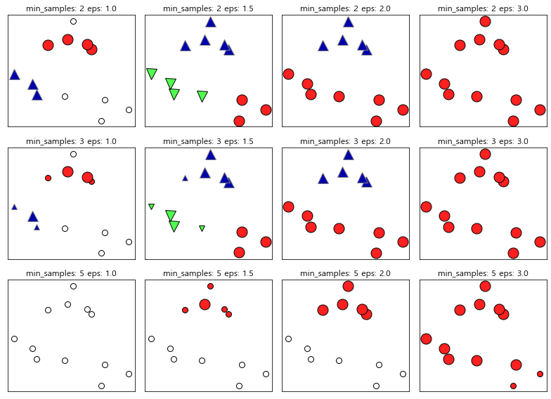

```python
mglearn.plots.plot_dbscan()
```

### 그림 설명

```
(1) core point(핵심 포인트) : 밀집 지역에 있는 포인트
   한 데이터 포인트에서 eps 거리 안에 데이터가 min_samples 개수만큼 들어 있다면.. 이 데이터를 핵심 샘플로 분류
(2) 잡음 포인트는 횐색으로 표시
(3) eps보다 가까운 핵심 샘플은 DBSCAN에 의해 동일한 클러스터로 합쳐진다.
(4) 핵심 샘플은 크게 표시. 경계 포인트는 작게 표시
(5) eps를 증가시키면 하나의 클러스터에 더 많은 포인트가 포함.
(6) min_samples설정은 포인트들이 잡음 포인트가 될지, 아니면 하나의 클러스터가 될지 결정하는데 중요 역할
```

### 포인트의 종류

```
핵심 샘플
경계 포인트 (핵심 포인트에서 eps 거리 안에 있는 포인트)
잡음 포인트

 * core point(핵심 샘플) : eps안에 min_samples보다 같거나 많다.
 * border point(경계 포인트) : eps안에 min_samples보다 작은데, core point가 있다.
 * noise point(잡음 포인트) : eps안에 min_samples보다 작고, 포인트중에 core point 가 없다. 어떤 클래스에소 소속되지 않는다.
```

### 05 실습해보기

### 데이터 준비 및 스케일 조정

```python
from sklearn.cluster import DBSCAN
from sklearn.datasets import make_moons
from sklearn.preprocessing import StandardScaler

X, y = make_moons(n_samples=200, noise=0.05, random_state=0)

# 평균 0, 분산 1이 되도록 데이터 스케일 조정
scaler = StandardScaler()
scaler.fit(X)
X_scaled = scaler.transform(X)
```

- 병합군집과 마찬가지로 DBSCAN은 새로운 데이터에 대해 예측할 수 없어, fit_predict메소드를 사용

```python
dbscan = DBSCAN()  # eps = 0.5, min_samples=5로 기본값
clusters = dbscan.fit_predict(X_scaled)
clusters
```

```
array([0, 1, 1, 0, 1, 1, 0, 1, 0, 1, 0, 1, 1, 1, 0, 0, 0, 1, 0, 0, 1, 1,
       0, 1, 0, 1, 1, 1, 1, 0, 0, 0, 1, 1, 0, 1, 1, 0, 0, 1, 1, 0, 0, 1,
       1, 0, 0, 0, 1, 1, 0, 1, 1, 0, 1, 0, 0, 1, 0, 0, 1, 0, 1, 0, 1, 0,
       0, 1, 0, 0, 1, 0, 1, 1, 1, 0, 1, 0, 0, 1, 1, 0, 1, 1, 1, 0, 0, 0,
       1, 1, 0, 0, 1, 0, 1, 1, 1, 1, 0, 1, 1, 1, 0, 0, 0, 1, 0, 0, 1, 0,
       0, 0, 0, 0, 0, 1, 0, 1, 1, 0, 0, 0, 1, 0, 1, 0, 0, 1, 1, 1, 0, 0,
       0, 1, 1, 1, 1, 0, 1, 0, 1, 1, 0, 0, 0, 0, 1, 1, 0, 1, 1, 1, 0, 0,
       1, 0, 1, 1, 0, 0, 1, 1, 0, 1, 1, 1, 0, 1, 1, 1, 0, 0, 0, 0, 1, 1,
       1, 0, 0, 0, 1, 0, 1, 1, 1, 0, 0, 1, 0, 0, 0, 0, 0, 0, 1, 0, 1, 1,
       0, 1], dtype=int64)
```

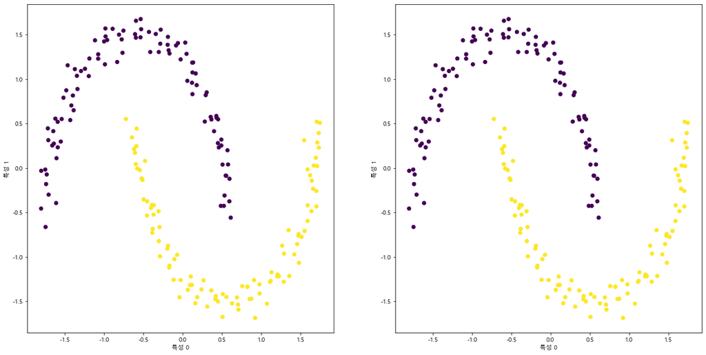

```python
# 원래 데이터 그래프
plt.figure(figsize=(20,10))
plt.subplot(1,2,1)   # 2행 1열에 첫번째
f1 = X_scaled[:, 0]  # 특성 첫번째 선택
f2 = X_scaled[:, 1]  # 특성 두번째 선택
plt.scatter(f1, f2, c=y)  # 원본 샘플 데이터
plt.xlabel("특성 0")
plt.ylabel("특성 1")

# DBSCAN 적용한 그래프
plt.subplot(1,2,2)   # 2행 1열에 두번째
f1 = X_scaled[:, 0]  # 특성 첫번째 선택
f2 = X_scaled[:, 1]  # 특성 두번째 선택
plt.scatter(f1, f2, c=clusters) # DBSCAN 적용한 샘플 데이터
plt.xlabel("특성 0")
plt.ylabel("특성 1")
```

- 예상한 클러스터 개수(2개)를 만들어내므로 매개변수 설정이 맞음.
- eps를 0.7로 올리면 하나의 클러스터를 만들어냄.
- DBSCAN을 사용할 때, 클러스터 할당값을 주의해서 다루어야 함.

### 실습

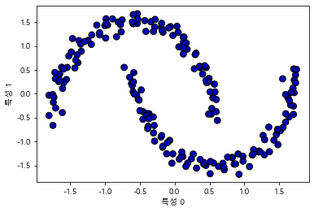

```python
dbscan = DBSCAN(eps=0.7, min_samples = 6)
clusters = dbscan.fit_predict(X_scaled)

f1 = X_scaled[:,0] # 첫번째 특성
f2 = X_scaled[:,1] # 두번째 특성

# 클러스터 할당을 표시한다.
plt.scatter(f1, f2, c=clusters,
           cmap=mglearn.cm2, s=60, edgecolors='black')
plt.xlabel("특성 0")
plt.ylabel("특성 1")
```

### REF

- https://towardsdatascience.com/dbscan-algorithm-complete-guide-and-application-with-python-scikit-learn-d690cbae4c5d

### 실습 풀이

- K-means 알고리즘을 적용한 y_pred를 구하고, 그래프 표시해 보기(3개)